# Implementation and Ethics of Automatic Online Data Collection

Anqi Shao, MS

Department of Life Sciences Communication

UW-Madison

Mar, 2023

# Introduction

## Three basic methodologies of quantitative communication research

- Survey
- Experiment
- Content Analysis

How do you get data for your research?

Are they ...

- Available?
- Accessible?
- Representive?
- Valid?

## Outline

- Our objectives today
- Webscrapers based on html parsing
- Retrieving social media content via APIs
- Here's the dataset, but what's next?

# Webscrapers based on html parsing

- What is HTML
- Browser -> right click -> inspect
- Different approaches to parse html data
- 5 minute demo

[figure not shown]

Q1: What if we want to download a large amount of contents from a website?

To scrape a website, which is usually written in html, we need to first understand the structure of it. Here's an example.

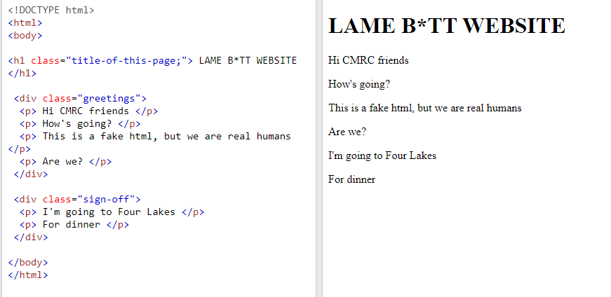

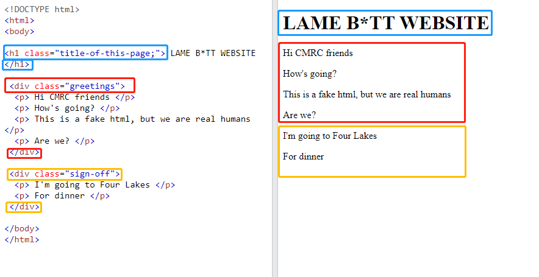

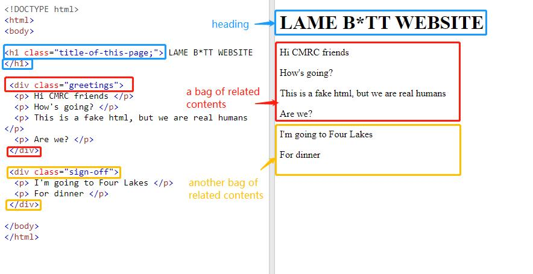

[figure not shown]

```python
#necessary libraries
import requests
from urllib.request import Request, urlopen
from bs4 import BeautifulSoup as soup
import pandas as pd
```

```python
url = "https://seedworld.com/?s=crispr" #what page are we looking at?

req = Request(url , headers={'User-Agent': 'Mozilla/5.0'}) # make a request to the URL with a specified User-Agent header

webpage = urlopen(req).read() # read the webpage content
soupy = soup(webpage, "html.parser") # parse the HTML content using BeautifulSoup

links = soupy.find_all("a", class_="td-image-wrap") # find all anchor tags with class "td-image-wrap"

link_list = []
#some loops to get all the article links here
for link in links:
  try:
    sub_content_url = link["href"]
  except: # if there is no href attribute, set sub_content_url to "NA"
    sub_content_url = "NA"
  link_list.append(sub_content_url)

print ("I have found " + str(len(link_list)) + " links in the page you provided.")
```

```
I have found 44 links in the page you provided.
```

```python
link_list_sub = link_list[0:5]
```

```python
df = pd.DataFrame(columns=["header", "time", "content"]) #create a dataframe to store our stuff


for link in link_list_sub:
  req = Request(link , headers={'User-Agent': 'Mozilla/5.0'})
  webpage = urlopen(req).read()
  soupy = soup(webpage, "html.parser")

  header = soupy.find("h1", class_="entry-title")
  header_text = header.text

  heady = soupy.find('header', class_='td-post-title')
  timer = heady.find("time", class_="entry-date updated td-module-date")
  timer_text = timer.text

  content = soupy.find("div", class_="td-ss-main-content")
  content_text = content.text

  df = df.append({"header": header_text, "time":timer_text, "content": content_text}, ignore_index=True)
```

```python
df.head()
```

[output not shown]

## Dynamic Scrapers

# Retrieving social media content via APIs

- What is an API?
- Social media APIs
- Obtaining API keys
- Third-party tools

# **API**

# **IRB**

# Got the data, but what's next?

- Rising ethical concerns of (automated) online data collection
- Even tighter data accessibility for the academia
- You don’t really need that much data
- You really need that much data

## Ethical concerns (as advertised)

- Copyright
- Privacy

Copyright

[figure not shown]

## Data accessibility for researchers

[figure not shown]

- Academic API not working as expected
- Restricted quota limit for data retrieving
- Higher expenses (Feb 2023)

[figure not shown]

## You don't really need that much data.

- ✅Larger sample size reduce Type II errors.
- ❗Messy large social media sample + simple OLS regressions can lead to trival shit findings

## You do really need that much data.

- For training machine learning models
- Low data efficiency in current machine learning algorithms

"You can't buy a picture book with 1 million pictures of giraffes."

-- Dr. Stuart Russel, OBE.

[figure not shown]